# 05 - Data Manipulation 2

27 March, 2018

## Overview

## Lesson Structure

This lesson We'll look at these functions, that work with `group_by()`:

- `arrange()`: order variables
- `select()`: pick out variables
- `filter()`: pick out observations
- `mutate()`: create new variables
- `summarise()`: create a summary of variables (e.g. mean, *SD*, n)

We'll also cover `rename()` for renaming variables.

## Getting Started

First, we'll load the packages necessary for this class. If you don't have lubridate, install it with `install.packages("lubridate")`.

```r
library(tidyverse)
library(lubridate)
```

Then load your data (already done in your class file).

```r
demo <- read_csv("inputs/lexical_decision_demographic_data_wide.csv")
```

## Understanding our Data

`glimpse()` trasposes data (with data type): see the first few observations of every column

```r
glimpse(demo)
```

```
## Observations: 29
## Variables: 14
## $ ID              <chr> "22", "23", "24", "25", "26", "27", "28", "29"...
## $ `C++`           <int> 1, 1, NA, 1, NA, NA, NA, NA, NA, 1, 1, NA, NA,...
## $ FORTRAN         <int> 1, NA, 1, 1, NA, 1, NA, NA, 1, 1, NA, NA, 1, N...
## $ JavaScript      <int> 1, NA, NA, NA, NA, 1, NA, 1, NA, 1, NA, NA, NA...
## $ Python          <int> NA, NA, NA, NA, 1, NA, NA, NA, NA, NA, NA, 1, ...
## $ R               <int> NA, NA, NA, NA, NA, NA, 1, NA, NA, NA, NA, 1, ...
## $ Ruby            <int> NA, NA, NA, NA, 1, NA, 1, NA, NA, NA, NA, NA, ...
## $ LANGUAGE        <chr> "OTHER", NA, "ENGLISH", NA, "english", "ENGLIS...
## $ progress        <chr> "FINISH", "no", "END", "ethics", "ethics", "EN...
## $ gender          <chr> "female", "male", "female", "male", "male", "f...
## $ age             <int> 30, 30, 30, 18, 31, 44, 23, 34, 32, 33, 20, 31...
## $ tester          <chr> "GW", "GW", "GW", "GW", "GW", "GW", "GW", "GW"...
## $ funRec          <chr> "7-no", "6-yes", "4-yes", "0-no", "4-no", "5-n...
## $ completion_time <chr> "2018-03-22 23:06:11_2018-03-23 00:25:51", "20...
```

## Preparing our Data

Let's separate **funRec** and **completion_time** using the `separate()` function from **tidyr**. This sort of tidying is common (see previous lesson).

```r
demo <- demo %>%
  separate(col = funRec, into = c("fun", "recommend")) %>%
  separate(col = completion_time, into = c("start", "end"), sep = "_")
glimpse(demo)
```

## Preparing our Data

```
## Observations: 29
## Variables: 16
## $ ID         <chr> "22", "23", "24", "25", "26", "27", "28", "29", "30...
## $ `C++`      <int> 1, 1, NA, 1, NA, NA, NA, NA, NA, 1, 1, NA, NA, NA, ...
## $ FORTRAN    <int> 1, NA, 1, 1, NA, 1, NA, NA, 1, 1, NA, NA, 1, NA, 1,...
## $ JavaScript <int> 1, NA, NA, NA, NA, 1, NA, 1, NA, 1, NA, NA, NA, NA,...
## $ Python     <int> NA, NA, NA, NA, 1, NA, NA, NA, NA, NA, NA, 1, NA, N...
## $ R          <int> NA, NA, NA, NA, NA, NA, 1, NA, NA, NA, NA, 1, 1, NA...
## $ Ruby       <int> NA, NA, NA, NA, 1, NA, 1, NA, NA, NA, NA, NA, NA, 1...
## $ LANGUAGE   <chr> "OTHER", NA, "ENGLISH", NA, "english", "ENGLISH", N...
## $ progress   <chr> "FINISH", "no", "END", "ethics", "ethics", "END", "...
## $ gender     <chr> "female", "male", "female", "male", "male", "female...
## $ age        <int> 30, 30, 30, 18, 31, 44, 23, 34, 32, 33, 20, 31, 33,...
## $ tester     <chr> "GW", "GW", "GW", "GW", "GW", "GW", "GW", "GW", "GW...
## $ fun        <chr> "7", "6", "4", "0", "4", "5", "0", "6", "1", "4", "...
## $ recommend  <chr> "no", "yes", "yes", "no", "no", "no", "no", "no", "...
## $ start      <chr> "2018-03-22 23:06:11", "2018-03-26 00:30:20", "2018...
## $ end        <chr> "2018-03-23 00:25:51", "2018-03-26 02:15:52", "2018...
```

## Selecting Columns

Can select by name or number.

```r
# by name
demo %>% select(ID,
                LANGUAGE,
                progress,
                gender,
                age,
                tester,
                fun,
                recommend,
                start,
                end
                )

# by number
demo %>% select(c(1, 8:16))
```

## Selecting Columns

Can select by name or number.

```
## # A tibble: 29 x 10
##    ID    LANGUAGE progress gender   age tester fun   recommend start end
##  * <chr> <chr>    <chr>    <chr>  <int> <chr>  <chr> <chr>     <chr> <chr>
##  1 22    OTHER    FINISH   female    30 GW     7     no        2018~ 2018~
##  2 23    <NA>     no       male      30 GW     6     yes       2018~ 2018~
##  3 24    ENGLISH  END      female    30 GW     4     yes       2018~ 2018~
##  4 25    <NA>     ethics   male      18 GW     0     no        2018~ 2018~
##  5 26    english  ethics   male      31 GW     4     no        2018~ 2018~
##  6 27    ENGLISH  END      female    44 GW     5     no        2018~ 2018~
##  7 28    <NA>     ethics   male      23 GW     0     no        2018~ 2018~
##  8 29    english  ethics   male      34 GW     6     no        2018~ 2018~
##  9 30    <NA>     <NA>     female    32 GW     1     yes       2018~ 2018~
## 10 A2    English  END      female    33 RHB    4     yes       2018~ 2018~
## # ... with 19 more rows
```

```
## # A tibble: 29 x 10
##    ID    LANGUAGE progress gender   age tester fun   recommend start end
##  * <chr> <chr>    <chr>    <chr>  <int> <chr>  <chr> <chr>     <chr> <chr>
##  1 22    OTHER    FINISH   female    30 GW     7     no        2018~ 2018~
##  2 23    <NA>     no       male      30 GW     6     yes       2018~ 2018~
##  3 24    ENGLISH  END      female    30 GW     4     yes       2018~ 2018~
##  4 25    <NA>     ethics   male      18 GW     0     no        2018~ 2018~
##  5 26    english  ethics   male      31 GW     4     no        2018~ 2018~
##  6 27    ENGLISH  END      female    44 GW     5     no        2018~ 2018~
##  7 28    <NA>     ethics   male      23 GW     0     no        2018~ 2018~
##  8 29    english  ethics   male      34 GW     6     no        2018~ 2018~
##  9 30    <NA>     <NA>     female    32 GW     1     yes       2018~ 2018~
## 10 A2    English  END      female    33 RHB    4     yes       2018~ 2018~
## # ... with 19 more rows
```

## Selecting Columns

Can also specify columns to drop (numbers 2 through to 7) with a minus

```r
demo_sub <- demo %>% select(-c(2:7))
demo_sub
```

```
## # A tibble: 29 x 10
##    ID    LANGUAGE progress gender   age tester fun   recommend start end
##  * <chr> <chr>    <chr>    <chr>  <int> <chr>  <chr> <chr>     <chr> <chr>
##  1 22    OTHER    FINISH   female    30 GW     7     no        2018~ 2018~
##  2 23    <NA>     no       male      30 GW     6     yes       2018~ 2018~
##  3 24    ENGLISH  END      female    30 GW     4     yes       2018~ 2018~
##  4 25    <NA>     ethics   male      18 GW     0     no        2018~ 2018~
##  5 26    english  ethics   male      31 GW     4     no        2018~ 2018~
##  6 27    ENGLISH  END      female    44 GW     5     no        2018~ 2018~
##  7 28    <NA>     ethics   male      23 GW     0     no        2018~ 2018~
##  8 29    english  ethics   male      34 GW     6     no        2018~ 2018~
##  9 30    <NA>     <NA>     female    32 GW     1     yes       2018~ 2018~
## 10 A2    English  END      female    33 RHB    4     yes       2018~ 2018~
## # ... with 19 more rows
```

## Selecting Columns

We have many select helpers, but we won't cover this here. Try to mess around with these helpers in your own time:

- `starts_with("string")`: keeps columns starting with "string"
- `ends_with("string")`: keeps columns ending with "string"
- `contains("string")`: keeps columns with names containing "string"
- `matches(regular_expression)`: keeps columns matching a **regular expression**
- `num_range("prefix", range)`: keeps columns with a matching prefix and a following range of numbers

## Renaming Columns

Takes the form, `rename(new name = old name)`

```r
demo_sub <- demo_sub %>% rename(language = LANGUAGE)
demo_sub
```

```
## # A tibble: 29 x 10
##    ID    language progress gender   age tester fun   recommend start end
##  * <chr> <chr>    <chr>    <chr>  <int> <chr>  <chr> <chr>     <chr> <chr>
##  1 22    OTHER    FINISH   female    30 GW     7     no        2018~ 2018~
##  2 23    <NA>     no       male      30 GW     6     yes       2018~ 2018~
##  3 24    ENGLISH  END      female    30 GW     4     yes       2018~ 2018~
##  4 25    <NA>     ethics   male      18 GW     0     no        2018~ 2018~
##  5 26    english  ethics   male      31 GW     4     no        2018~ 2018~
##  6 27    ENGLISH  END      female    44 GW     5     no        2018~ 2018~
##  7 28    <NA>     ethics   male      23 GW     0     no        2018~ 2018~
##  8 29    english  ethics   male      34 GW     6     no        2018~ 2018~
##  9 30    <NA>     <NA>     female    32 GW     1     yes       2018~ 2018~
## 10 A2    English  END      female    33 RHB    4     yes       2018~ 2018~
## # ... with 19 more rows
```

## Reordering Columns

Use `select()` to reorder columns by specifying columns to keep in order. `everything()` helps if you want to keep the same original order after things you've specified.

```r
demo_sub %>% select(ID, age, gender, everything())
```

```
## # A tibble: 29 x 10
##    ID      age gender language progress tester fun   recommend start end
##  * <chr> <int> <chr>  <chr>    <chr>    <chr>  <chr> <chr>     <chr> <chr>
##  1 22       30 female OTHER    FINISH   GW     7     no        2018~ 2018~
##  2 23       30 male   <NA>     no       GW     6     yes       2018~ 2018~
##  3 24       30 female ENGLISH  END      GW     4     yes       2018~ 2018~
##  4 25       18 male   <NA>     ethics   GW     0     no        2018~ 2018~
##  5 26       31 male   english  ethics   GW     4     no        2018~ 2018~
##  6 27       44 female ENGLISH  END      GW     5     no        2018~ 2018~
##  7 28       23 male   <NA>     ethics   GW     0     no        2018~ 2018~
##  8 29       34 male   english  ethics   GW     6     no        2018~ 2018~
##  9 30       32 female <NA>     <NA>     GW     1     yes       2018~ 2018~
## 10 A2       33 female English  END      RHB    4     yes       2018~ 2018~
## # ... with 19 more rows
```

## Creating and Changing Columns

- `mutate()` allows you to create a new column
- You can do this from manipulations to old columns (or not)
- Set a column to a mutated version of itself to change a column, e.g.:
- Can refer to just-created columns to make new columns

```r
# requires lubridate for ymd_hms() function
demo_sub <- demo_sub %>%
  mutate(start = ymd_hms(start),
         end = ymd_hms(end),
         time = end - start
         )
glimpse(demo_sub)
```

## Creating and Changing Columns

```
## Observations: 29
## Variables: 11
## $ ID        <chr> "22", "23", "24", "25", "26", "27", "28", "29", "30"...
## $ language  <chr> "OTHER", NA, "ENGLISH", NA, "english", "ENGLISH", NA...
## $ progress  <chr> "FINISH", "no", "END", "ethics", "ethics", "END", "e...
## $ gender    <chr> "female", "male", "female", "male", "male", "female"...
## $ age       <int> 30, 30, 30, 18, 31, 44, 23, 34, 32, 33, 20, 31, 33, ...
## $ tester    <chr> "GW", "GW", "GW", "GW", "GW", "GW", "GW", "GW", "GW"...
## $ fun       <chr> "7", "6", "4", "0", "4", "5", "0", "6", "1", "4", "3...
## $ recommend <chr> "no", "yes", "yes", "no", "no", "no", "no", "no", "y...
## $ start     <dttm> 2018-03-22 23:06:11, 2018-03-26 00:30:20, 2018-03-2...
## $ end       <dttm> 2018-03-23 00:25:51, 2018-03-26 02:15:52, 2018-03-2...
## $ time      <time> 1.327778 hours, 1.758889 hours, 1.113889 hours, 1.6...
```

## Creating and Only Keeping New Columns

`transmute()` is like `mutate()` but only keeps the new cols.

```r
# calculate difference from mean completion time
transmuted_time <- demo_sub %>%
  mutate(
    start = ymd_hms(start),
    end = ymd_hms(end),
    time = end - start
  ) %>%
  transmute(
    ID,
    time_diff = time - mean(time)
  )

units(transmuted_time$time_diff) <- "mins" # define units
transmuted_time # print the object
```

## Creating and Only Keeping New Columns

`transmute()` is like `mutate()` but only keeps the new cols.

```r
transmuted_time # print the object
```

```
## # A tibble: 29 x 2
##    ID    time_diff
##    <chr> <time>
##  1 22    -7.18563218390805
##  2 23    18.6810344827586
##  3 24    -20.0189655172414
##  4 25    14.5977011494253
##  5 26    4.13103448275861
##  6 27    -22.785632183908
##  7 28    17.4810344827586
##  8 29    8.14770114942528
##  9 30    -13.9022988505747
## 10 A2    -5.86896551724138
## # ... with 19 more rows
```

## Filtering to Observations

How many labels do we have for progress?

```r
unique(demo_sub$progress)
```

```
## [1] "FINISH" "no"     "END"    "ethics" NA
```

- We have a few labels: FINISH, no, END, ethics, and NA.
- Filter: **FINISH** and **END**

## Filtering with Logical Operations

These two are equivalent.

1. filters where progress values ares equal to (`==`) "FINISH" *or* (`|`) END

Use the second when you have many OR statements.

```r
demo_sub %>% filter(progress == "FINISH" | progress == "END")
```

```
## # A tibble: 23 x 11
##    ID    language progress gender       age tester fun   recommend
##    <chr> <chr>    <chr>    <chr>      <int> <chr>  <chr> <chr>
##  1 22    OTHER    FINISH   female        30 GW     7     no
##  2 24    ENGLISH  END      female        30 GW     4     yes
##  3 27    ENGLISH  END      female        44 GW     5     no
##  4 A2    English  END      female        33 RHB    4     yes
##  5 A3    Other    END      male          20 RHB    3     no
##  6 C     English  END      female        31 RHB    1     yes
##  7 D     Other    END      non-binary    33 RHB    5     yes
##  8 I     Other    END      male          36 RHB    5     no
##  9 J     Other    END      female        28 RHB    6     yes
## 10 K     English  END      male          33 RHB    1     yes
## # ... with 13 more rows, and 3 more variables: start <dttm>, end <dttm>,
## #   time <time>
```

## Filtering with Logical Operations

These two are equivalent.

1. filters where FINISH or END values are in (`%in%`) progress column

Use the second when you have many OR statements.

```r
demo_sub %>% filter(progress %in% c("FINISH", "END"))
```

```
## # A tibble: 23 x 11
##    ID    language progress gender       age tester fun   recommend
##    <chr> <chr>    <chr>    <chr>      <int> <chr>  <chr> <chr>
##  1 22    OTHER    FINISH   female        30 GW     7     no
##  2 24    ENGLISH  END      female        30 GW     4     yes
##  3 27    ENGLISH  END      female        44 GW     5     no
##  4 A2    English  END      female        33 RHB    4     yes
##  5 A3    Other    END      male          20 RHB    3     no
##  6 C     English  END      female        31 RHB    1     yes
##  7 D     Other    END      non-binary    33 RHB    5     yes
##  8 I     Other    END      male          36 RHB    5     no
##  9 J     Other    END      female        28 RHB    6     yes
## 10 K     English  END      male          33 RHB    1     yes
## # ... with 13 more rows, and 3 more variables: start <dttm>, end <dttm>,
## #   time <time>
```

## Combining Filtering Criteria

Add filters by other columns with a comma. You can use different operators to filter.

```r
demo_sub %>% filter(progress %in% c("FINISH", "END"),
                    tester == "RHB",
                    age > 30
                    )
```

```
## # A tibble: 9 x 11
##   ID    language progress gender       age tester fun   recommend
##   <chr> <chr>    <chr>    <chr>      <int> <chr>  <chr> <chr>
## 1 A2    English  END      female        33 RHB    4     yes
## 2 C     English  END      female        31 RHB    1     yes
## 3 D     Other    END      non-binary    33 RHB    5     yes
## 4 I     Other    END      male          36 RHB    5     no
## 5 K     English  END      male          33 RHB    1     yes
## 6 R1    English  END      female        31 RHB    6     yes
## 7 R3    English  END      female        35 RHB    0     no
## 8 V     Other    END      male          37 RHB    7     no
## 9 W1    English  END      non-binary    31 RHB    1     no
## # ... with 3 more variables: start <dttm>, end <dttm>, time <time>
```

## Removing by Ceriteria

Which columns should we **not** keep? Use `!` (read: not) before criteria. - This only gives you people who didn't finish.

```r
demo_sub %>% filter(!progress %in% c("FINISH", "END"))
```

```
## # A tibble: 6 x 11
##   ID    language progress gender   age tester fun   recommend
##   <chr> <chr>    <chr>    <chr>  <int> <chr>  <chr> <chr>
## 1 23    <NA>     no       male      30 GW     6     yes
## 2 25    <NA>     ethics   male      18 GW     0     no
## 3 26    english  ethics   male      31 GW     4     no
## 4 28    <NA>     ethics   male      23 GW     0     no
## 5 29    english  ethics   male      34 GW     6     no
## 6 30    <NA>     <NA>     female    32 GW     1     yes
## # ... with 3 more variables: start <dttm>, end <dttm>, time <time>
```

## Handling NAs

This won't run…

```r
demo_sub %>% filter(language == NA)
```

Instead, use `is.na()`, to check whether these values are NAs.

```r
demo_sub %>% filter(is.na(language))
```

```
## # A tibble: 4 x 11
##   ID    language progress gender   age tester fun   recommend
##   <chr> <chr>    <chr>    <chr>  <int> <chr>  <chr> <chr>
## 1 23    <NA>     no       male      30 GW     6     yes
## 2 25    <NA>     ethics   male      18 GW     0     no
## 3 28    <NA>     ethics   male      23 GW     0     no
## 4 30    <NA>     <NA>     female    32 GW     1     yes
## # ... with 3 more variables: start <dttm>, end <dttm>, time <time>
```

## Handling NAs

Default filtering = exclude things that don't meet criteria, and NAs.

Here we will filter those who finished the experiment, or who we're unsure about.

```r
demo_sub %>% filter(progress == "FINISH" | progress == "END" | is.na(progress))
```

```
## # A tibble: 24 x 11
##    ID    language progress gender       age tester fun   recommend
##    <chr> <chr>    <chr>    <chr>      <int> <chr>  <chr> <chr>
##  1 22    OTHER    FINISH   female        30 GW     7     no
##  2 24    ENGLISH  END      female        30 GW     4     yes
##  3 27    ENGLISH  END      female        44 GW     5     no
##  4 30    <NA>     <NA>     female        32 GW     1     yes
##  5 A2    English  END      female        33 RHB    4     yes
##  6 A3    Other    END      male          20 RHB    3     no
##  7 C     English  END      female        31 RHB    1     yes
##  8 D     Other    END      non-binary    33 RHB    5     yes
##  9 I     Other    END      male          36 RHB    5     no
## 10 J     Other    END      female        28 RHB    6     yes
## # ... with 14 more rows, and 3 more variables: start <dttm>, end <dttm>,
## #   time <time>
```

## Handling NAs

Or we could do the opposite, dropping these observations.

```r
demo_sub %>% filter(!progress %in% c("FINISH", "END") & !is.na(progress))
```

```
## # A tibble: 5 x 11
##   ID    language progress gender   age tester fun   recommend
##   <chr> <chr>    <chr>    <chr>  <int> <chr>  <chr> <chr>
## 1 23    <NA>     no       male      30 GW     6     yes
## 2 25    <NA>     ethics   male      18 GW     0     no
## 3 26    english  ethics   male      31 GW     4     no
## 4 28    <NA>     ethics   male      23 GW     0     no
## 5 29    english  ethics   male      34 GW     6     no
## # ... with 3 more variables: start <dttm>, end <dttm>, time <time>
```

## Arranging Data

`arrange()` by any number of variables. Goes from smallest to largest values.

```r
demo_sub %>% arrange(ID)
```

```
## # A tibble: 29 x 11
##    ID    language progress gender   age tester fun   recommend
##    <chr> <chr>    <chr>    <chr>  <int> <chr>  <chr> <chr>
##  1 22    OTHER    FINISH   female    30 GW     7     no
##  2 23    <NA>     no       male      30 GW     6     yes
##  3 24    ENGLISH  END      female    30 GW     4     yes
##  4 25    <NA>     ethics   male      18 GW     0     no
##  5 26    english  ethics   male      31 GW     4     no
##  6 27    ENGLISH  END      female    44 GW     5     no
##  7 28    <NA>     ethics   male      23 GW     0     no
##  8 29    english  ethics   male      34 GW     6     no
##  9 30    <NA>     <NA>     female    32 GW     1     yes
## 10 A2    English  END      female    33 RHB    4     yes
## # ... with 19 more rows, and 3 more variables: start <dttm>, end <dttm>,
## #   time <time>
```

## Arranging Data

Arrange by tester, then by start time within tester.

```r
demo_sub %>% arrange(tester, start)
```

```
## # A tibble: 29 x 11
##    ID    language progress gender   age tester fun   recommend
##    <chr> <chr>    <chr>    <chr>  <int> <chr>  <chr> <chr>
##  1 27    ENGLISH  END      female    44 GW     5     no
##  2 24    ENGLISH  END      female    30 GW     4     yes
##  3 30    <NA>     <NA>     female    32 GW     1     yes
##  4 22    OTHER    FINISH   female    30 GW     7     no
##  5 26    english  ethics   male      31 GW     4     no
##  6 29    english  ethics   male      34 GW     6     no
##  7 25    <NA>     ethics   male      18 GW     0     no
##  8 28    <NA>     ethics   male      23 GW     0     no
##  9 23    <NA>     no       male      30 GW     6     yes
## 10 S     English  END      female    25 RHB    4     no
## # ... with 19 more rows, and 3 more variables: start <dttm>, end <dttm>,
## #   time <time>
```

## Arranging Data

Largest to smallest, using the `desc()` function (read: descending):

```r
demo_sub %>% arrange(desc(ID))
```

```
## # A tibble: 29 x 11
##    ID    language progress gender       age tester fun   recommend
##    <chr> <chr>    <chr>    <chr>      <int> <chr>  <chr> <chr>
##  1 Z     Other    END      female        28 RHB    0     no
##  2 W2    English  END      female        29 RHB    1     yes
##  3 W1    English  END      non-binary    31 RHB    1     no
##  4 V     Other    END      male          37 RHB    7     no
##  5 T2    Other    END      male          27 RHB    0     yes
##  6 T1    English  END      male          22 RHB    4     no
##  7 S     English  END      female        25 RHB    4     no
##  8 R3    English  END      female        35 RHB    0     no
##  9 R2    English  END      non-binary    27 RHB    5     no
## 10 R1    English  END      female        31 RHB    6     yes
## # ... with 19 more rows, and 3 more variables: start <dttm>, end <dttm>,
## #   time <time>
```

## Summarising Data

- `summarise()` collapses across all observations and creates a table.
- You only get columns you request; here we make the column mean_time by calculating `mean()` on time

```r
demo_sub %>% summarise(mean_time = mean(time))
```

```
## # A tibble: 1 x 1
##   mean_time
##   <time>
## 1 1.44753831417625
```

## Summarising Data

We can add more columns by separating them with a comma:

```r
demo_sub %>%
  summarise(mean_time = mean(time),
           sd_time = sd(time),
           N = n()
           )
```

```
## # A tibble: 1 x 3
##   mean_time        sd_time               N
##   <time>           <time>            <int>
## 1 1.44753831417625 0.275443582881955    29
```

## Summarising Data

`summarise()` doesn't play well with NAs.

```r
demo_sub %>%
  mutate(time = replace(time, 1, NA)) %>%
  summarise(mean_time = mean(time),
           sd_time = sd(time),
           N = n()
           )
```

```
## # A tibble: 1 x 3
##   mean_time sd_time     N
##   <time>    <time>  <int>
## 1 <NA>      NaN        29
```

## Summarising Data

`summarise()` doesn't play well with NAs. So we have to tell it to ignore them.

```r
demo_sub %>%
  mutate(time = replace(time, 1, NA)) %>%
  summarise(mean_time = mean(time, na.rm = TRUE),
           sd_time = sd(time, na.rm = TRUE),
           N = n()
           )
```

```
## # A tibble: 1 x 3
##   mean_time        sd_time               N
##   <time>           <time>            <int>
## 1 1.45181547619048 0.279515577285935    29
```

## Grouping Data

- `group_by` allows you to perform the previous operations on groups of data.
- Most often used with `summarise()` for group summaries

```r
demo_sub %>%
  group_by(language) %>%
  summarise(mean_time = mean(time, na.rm = TRUE),
           sd_time = sd(time, na.rm = TRUE),
           N = n()
           )
```

```
## # A tibble: 6 x 4
##   language mean_time        sd_time                N
##   <chr>    <time>           <time>             <int>
## 1 english  1.54986111111111 0.0473368706294328     2
## 2 English  1.41704545454545 0.26597344132959      11
## 3 ENGLISH  1.09083333333333 0.0326054793547131     2
## 4 Other    1.48638888888889 0.317281110753131      9
## 5 OTHER    1.32777777777778 NaN                    1
## 6 <NA>     1.60111111111111 0.258434767023681      4
```

## Grouping Data

Identifies unique observations in your grouped column, so be sure you pass the right information along!

```r
demo_sub %>%
  mutate(language = tolower(language)) %>%
  group_by(language) %>%
  summarise(mean_time = mean(time, na.rm = TRUE),
           sd_time = sd(time, na.rm = TRUE),
           N = n()
           )
```

```
## # A tibble: 3 x 4
##   language mean_time        sd_time               N
##   <chr>    <time>           <time>            <int>
## 1 english  1.39125925925926 0.260337334300721    15
## 2 other    1.47052777777778 0.303311384194351    10
## 3 <NA>     1.60111111111111 0.258434767023681     4
```

## Grouping Data

```r
demo_sub %>%
  mutate(language = tolower(language)) %>%
  group_by(language) %>%
  filter(rank(time) == 1) %>%
  glimpse()
```

```
## Observations: 3
## Variables: 11
## $ ID        <chr> "27", "30", "J"
## $ language  <chr> "english", NA, "other"
## $ progress  <chr> "END", NA, "END"
## $ gender    <chr> "female", "female", "female"
## $ age       <int> 44, 32, 28
## $ tester    <chr> "GW", "GW", "RHB"
## $ fun       <chr> "5", "1", "6"
## $ recommend <chr> "no", "yes", "yes"
## $ start     <dttm> 2018-03-21 03:23:57, 2018-03-22 04:16:08, 2018-03-2...
## $ end       <dttm> 2018-03-21 04:28:01, 2018-03-22 05:29:05, 2018-03-2...
## $ time      <time> 1.067778 hours, 1.215833 hours, 1.073056 hours
```

## Ungrouping Data

Use `ungroup()` if you want to go back to ungrouped data.

```r
demo_sub %>%
  mutate(language = tolower(language)) %>%
  group_by(language) %>%
  filter(rank(time) != 1) %>%
  ungroup() %>%
  summarise(mean_time = mean(time, na.rm = TRUE),
            sd_time = sd(time, na.rm = TRUE),
            N = n()
            )
```

```
## # A tibble: 1 x 3
##   mean_time       sd_time               N
##   <time>          <time>            <int>
## 1 1.4854594017094 0.264484846847179    26
```

## Chaining Many Functions

We can do all our data cleaning in 1 chain (or by several pipes)

```r
# load, clean, and transform data
demo_clean <- read_csv("inputs/lexical_decision_demographic_data_wide.csv") %>%
  separate(col = funRec, into = c("fun", "recommend")) %>%
  separate(col = completion_time, into = c("start", "end"), sep = "_") %>%
  select(c(1, 8:16)) %>%
  rename(language = LANGUAGE) %>%
  mutate(start = ymd_hms(start),
         end = ymd_hms(end),
         time = end - start,
         language = tolower(language)
         )
```

## Chaining Many Functions

Pass this along to any summary code

```r
demo_clean %>%
  group_by(language) %>%
  summarise(mean_time = mean(time, na.rm = TRUE),
           sd_time = sd(time, na.rm = TRUE),
           N = n()
           )
```

```
## # A tibble: 3 x 4
##   language mean_time        sd_time               N
##   <chr>    <time>           <time>            <int>
## 1 english  1.39125925925926 0.260337334300721    15
## 2 other    1.47052777777778 0.303311384194351    10
## 3 <NA>     1.60111111111111 0.258434767023681     4
```

## Chaining Many Functions

Pass this along to any plotting code

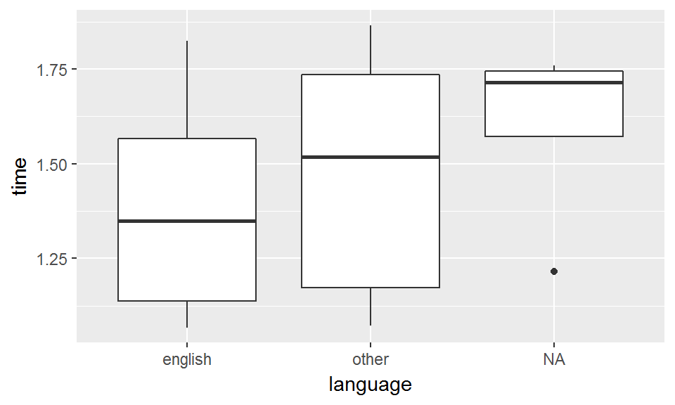

```r
demo_clean %>%
  ggplot(mapping = aes(x = language, y = time)) +
  geom_boxplot()
```

## Saving your Data

### CSVs

Save as a .csv for platform-agnostic data

```r
write_csv(demo_clean, "outputs/filtered_demographic_data.csv")
```

### RData Files

Keeps data types, less storage space, allows advanced data layouts (e.g. nested, model outputs)

```r
save(demo_clean, file = "outputs/filtered_demographic_data.RData")
```

Load it back up in another session with

```r
load("outputs/filtered_demographic_data.RData")
```

## A Final Note

There are many variants of the functions we've used. Use `?function name` (e.g. `?mutate()`) to find out more about them. Often, you can save typing if you want to mutate several columns using some variant of `mutate()`.

Examples:

- `summarise_if()`, `mutate_if()`, `transmute_if()`: operations on columns where if statement returns TRUE (e.g. `if(is.numeric())`)
- `summarise_at()`, `mutate_at()`, `transmute_at()`: use `select()` helpers to grab column names
- `summarise_all()`, `mutate_all()`, `transmute_all()`: apply functions to all non-grouped columns